# Covid-19

S.Abishanya

July 18, 2020

# **COVID-19 pandemic in Turkey**

### location

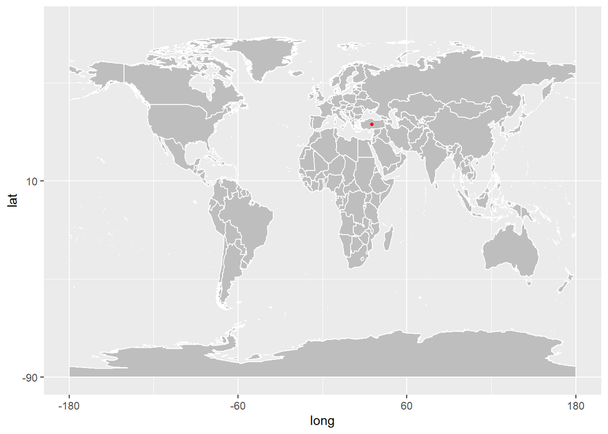

### Climate condition

Although Turkey is situated in a geographical location where climatic conditions are quite temperate diverse nature of the landscape, and the existence in particular of the mountains that run parallel to the coasts, result in significant differences in climatic conditions from one region to the other. While the coastal areas enjoy milder climates, the inland Anatolian plateau experiences extremes of hot summers and cold winters with limited rainfall. Turkey receives most of the rainfall in the winter season. In this season, mean temperature usually is below 5 and there is no too much evaporation. But summer rainfall is very limited and could not be enough to remove water deficit resulted from increased temperature and evaporation. The Aegean and Mediterranean coasts have cool, rainy winters and hot, moderately dry summers. Annual precipitation in those areas varies from 580 to 1,300 millimeters, depending on location. The Black Sea coast receives the greatest amount of rainfall. The eastern part of that receives 2,200 millimeters annually and is the only region of Turkey that receives rainfall throughout the year.

### Action taken by goverment

##### Education

On 8 March, the Ministry of National Education announced that they were using special disinfectants to keep schools clean against the virus threat after that all schools in Turkey would be closed starting from 16 March 2020 for a week. The remote classes for primary, secondary and high schools started on 23 March 2020 on TRT EBA TV, a channel created through the collaboration of TRT and the Ministry of Education

##### Travel Restriction

Turkey closed all board gates and announced that pavilions, discotheques, bars and night clubs would be closed temporarily starting from 10:00 on 16 March, On 16 March announced a nationwide ban on prayer gatherings in mosques, including Friday prayers, due to the pandemic and temporarily closing all public gathering places such as cafes, gyms, Internet cafes and movie theaters, except shops and restaurants not offering music, starting midnight the following day

##### Economics

Turkey goverment announced stated that public banks will deliver pensions to retirees above the age of 76 to their homes, with the minimum amount of payment for retired people being ???1,500.The Banks Association of Turkey also sent a notice to different banks across the country and limited their working hours to 12:00 pm to 5:00 pm, which went into effect on 23 March 2020.Some of the economic measures taken by the Turkish government are; describing the pandemic as a force majeure event as per public procurement contracts, postponement of general assembly meetings, limitations on dividend distribution, flexibility on rent payments, modification on short time working and compensatory work rules, export control on disinfectants, medical diagnostic kits, masks and intensive care equipment.

### summary of COVID 19 in Turkey

| Type | Cases |
| --- | --- |
| confirmed cases | 141475 |
| death | 3894 |
| recovered | 98889 |

### Daily confirmed cases in Turkey

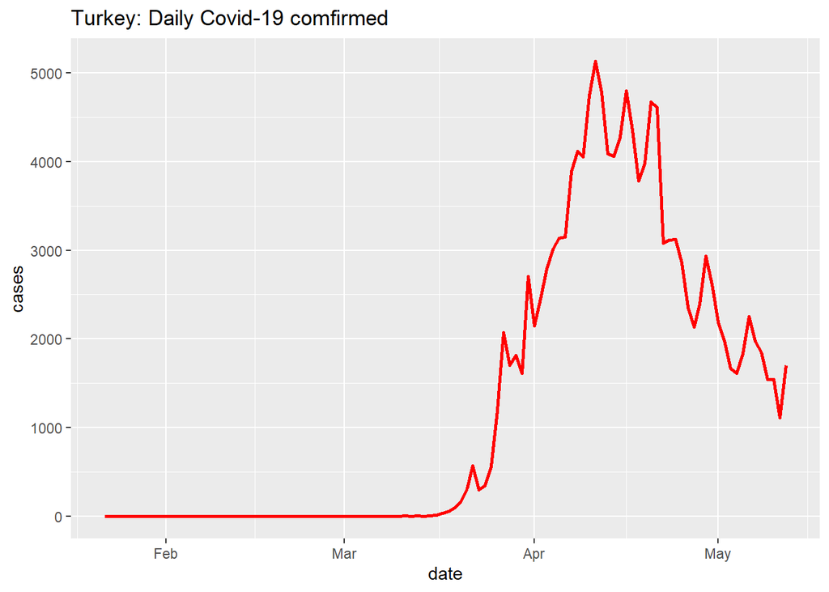

Middle of the March confirmed cases ofcovid 19 founded in Turkey,up to middle of April corona virus effect increased and after April it became decreasing, maximum number (5138 cases) of confirm cases founded on 11th of April 2020 and in April month Tukey also highly effected by corona virus.

### Daily death cases in Turkey

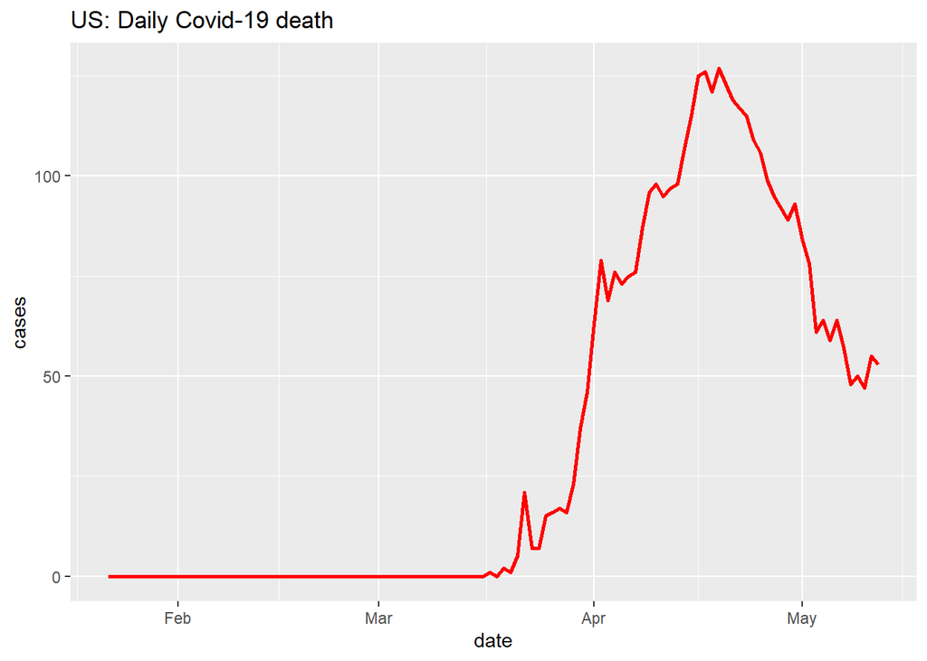

On 15 first covid-19 death founded in Turkey, death rate increased up to middle of April and it decreased, high deaths founded 3rd week of April.maximun number of death (127 cases) founded on 19th of April 2020.

### Daily recovered cases in Turkey

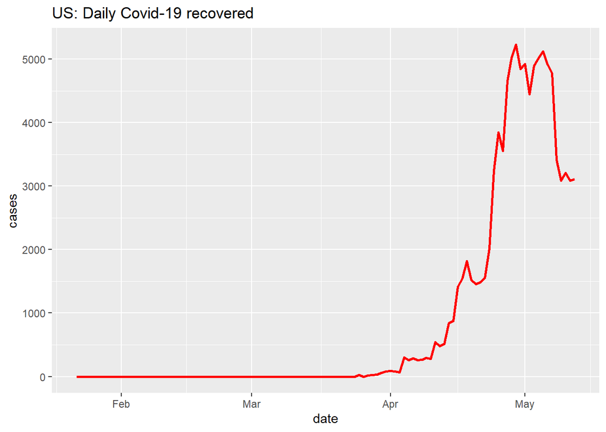

### Daily active cases in Turkey

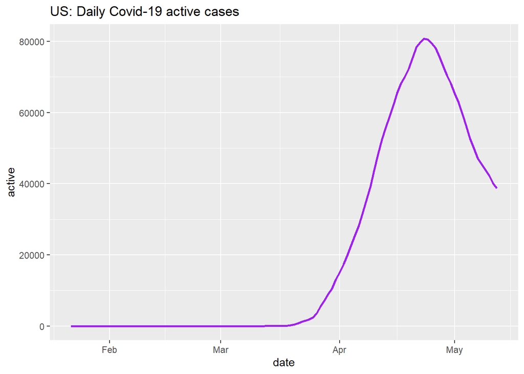

Daily active cases increased during April month, that mean in April month covid-19 highly effected in Turkey.

### Turkey vs China

#### daily confirmed cases

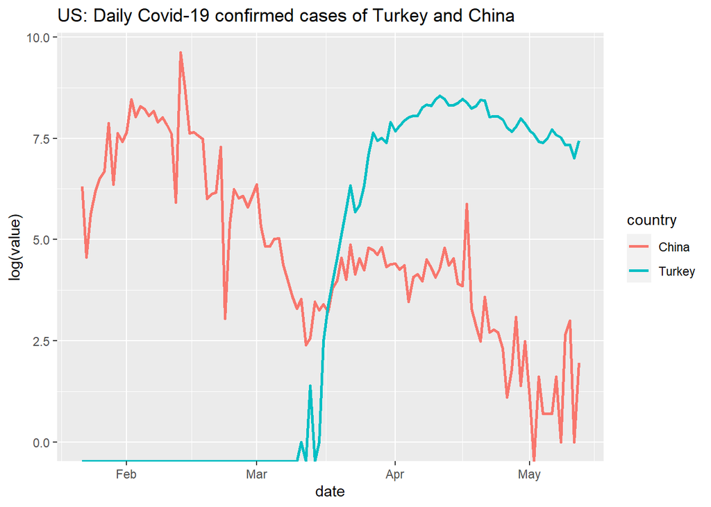

compared confirmed cases with China covid-19 confirmed cases,when china covid-19 cases decreased that time Turkey founded covid-19 increasing in their country.

#### daily recovered cases

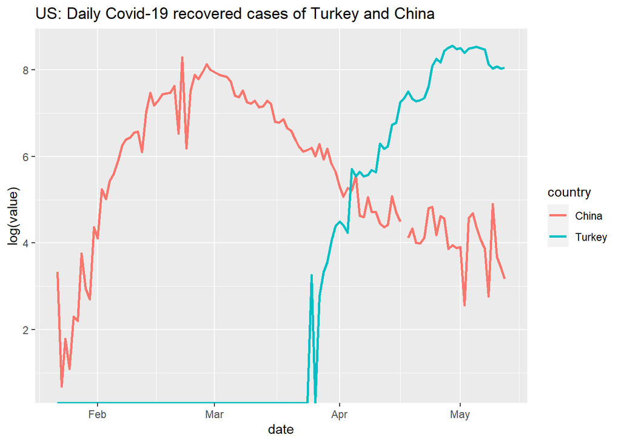

Compared the recovered rate with Covid-19 recovery rate,recovery rate high china when the Turkey found confirmed covid-19 cases and after April it became high compared with China recovery patients rate.

#### daily death cases

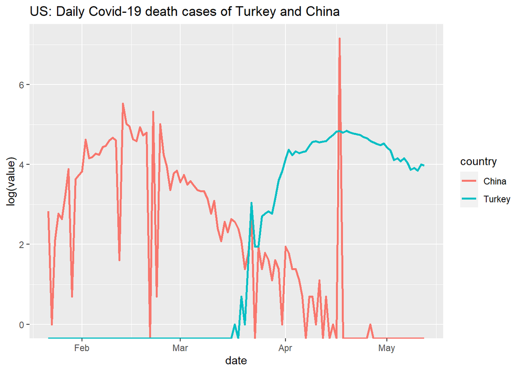

When the death rate high in China that time there was no confirmed founded in Turkey,but end of the March death rate was approximately equal in both countries and after few days Turkey Covid-19 death rate increasesd, On 16 0f April 2020 death cases is maximum in China.

### Turkey vs US

#### daily confirmed cases

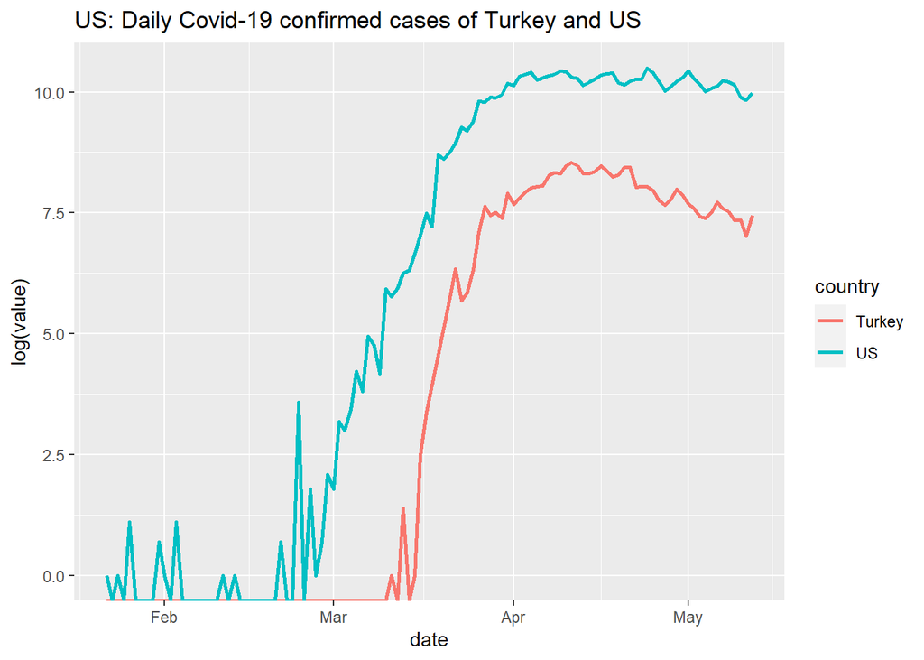

Confim cases in Turkey is low when compared with USA.USA confirmed the covid-19 cases before the Turkey but USA daily confirm cases high.

#### daily recovered cases

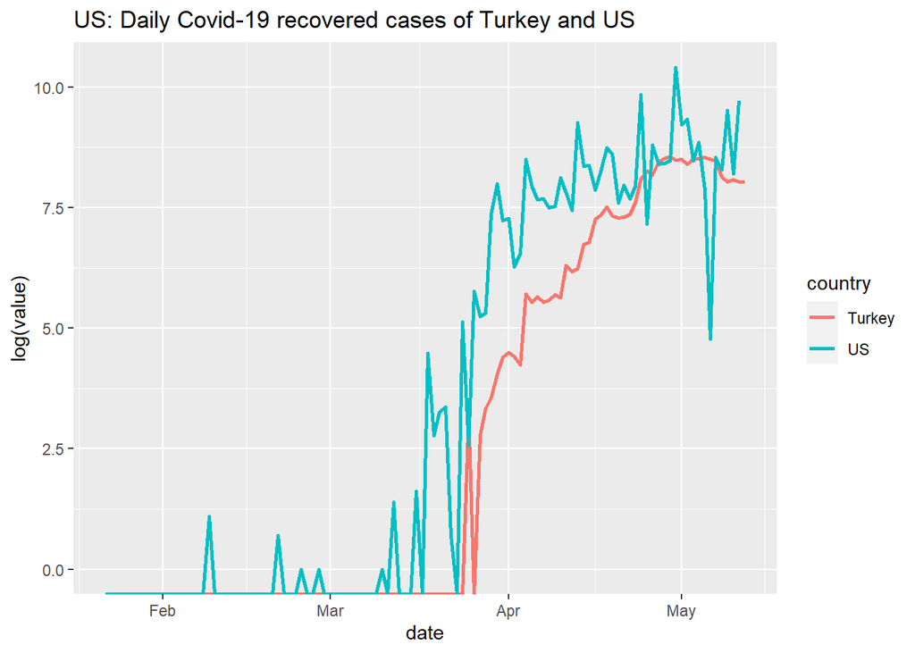

#### daily death cases

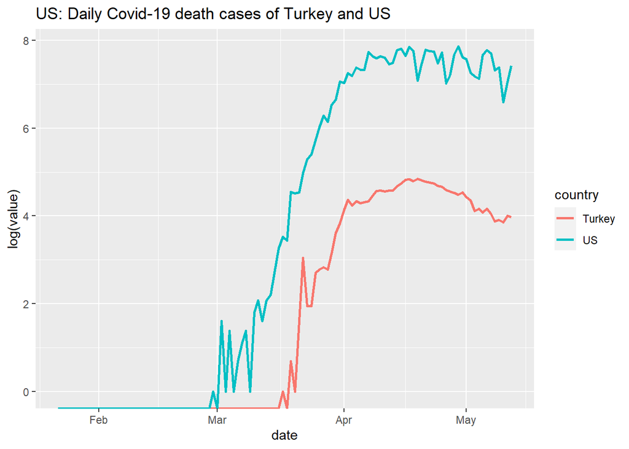

Daily death rate in Turkey was low when compared with USA death rate,it because of USA daily confirmed cases were high when compared with Turkey.

### Turkey vs Syria

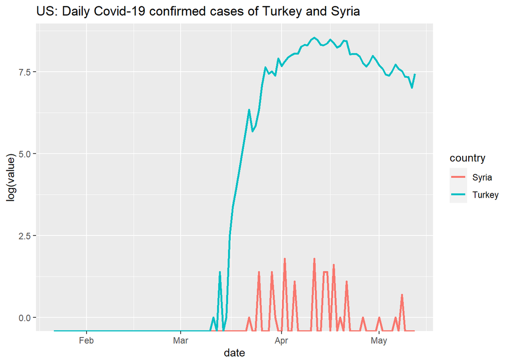

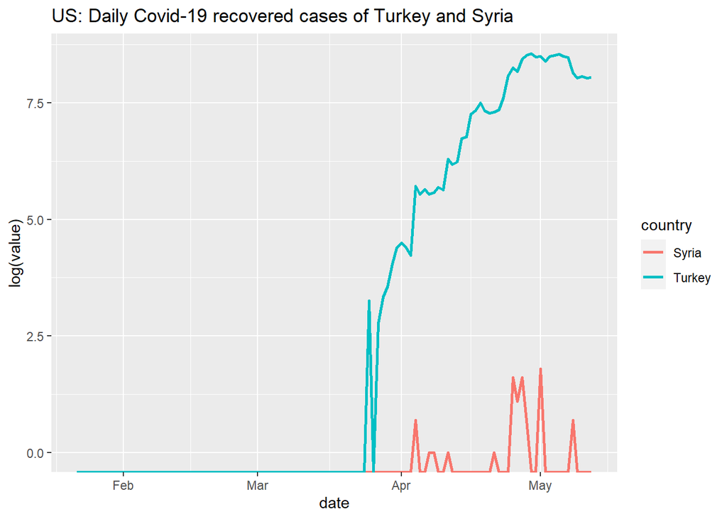

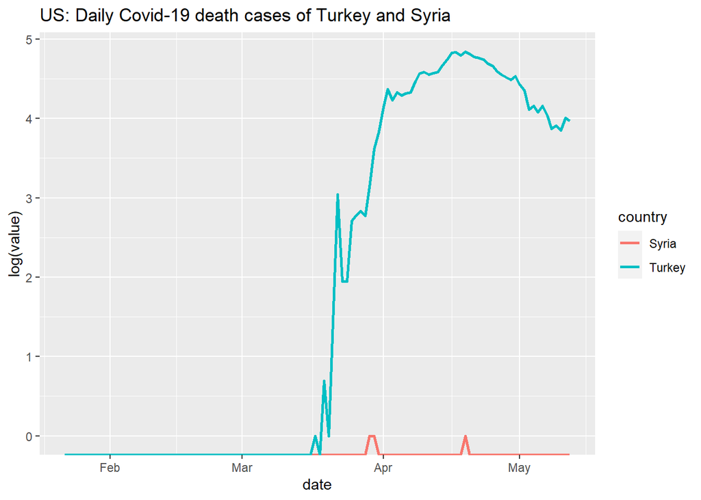

Syria isone of the nearest country to Turkey but covid-19 cases were very low when we compared with Turkey, compared with Syria daily confirmed cases, death cases and recovered cases were very high in Turkey.

### confirmed cases in the countries

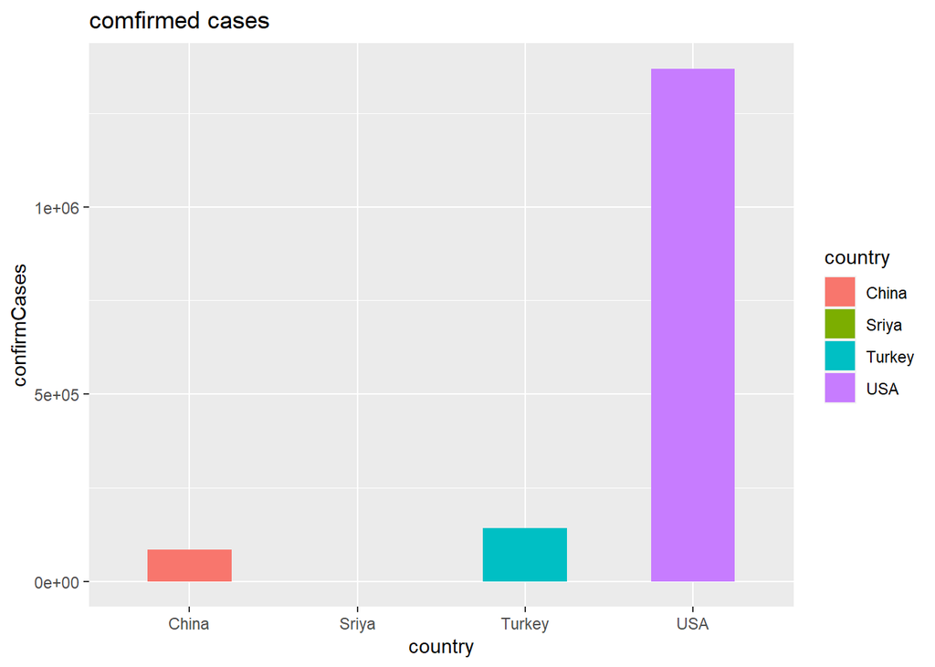

When compared the total confirned cases with the countries,among the 4 countrie total confirmed cases in USA was very high and total confirmed cases in Syria was very low, when compared total confirmed cases in Turkey with other countries Total confirm cases in Turkey was higher than Syria, China and also lower than USA.

### death cases in the countries

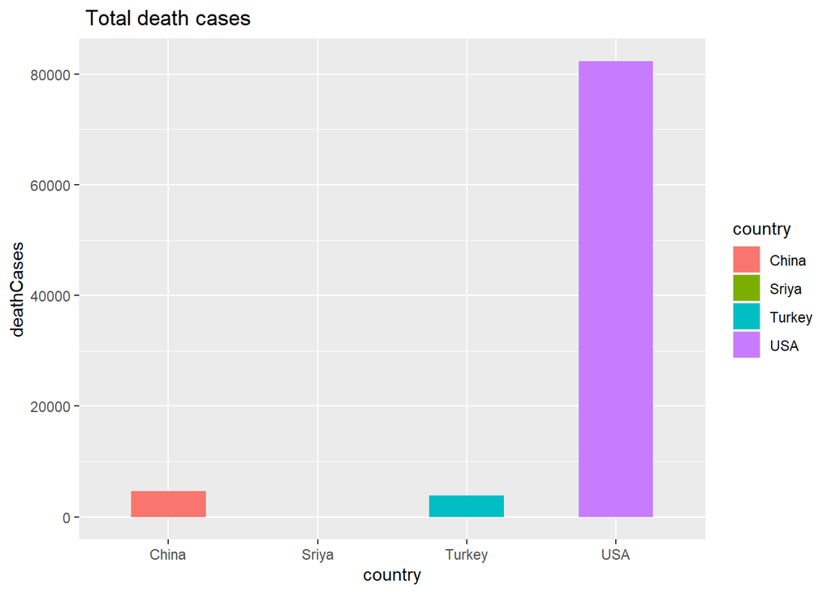

When compared the total death cases with the countries,among the 4 countrie total death cases in USA was very high and total death cases in Syria was very low, when compared total death cases in Turkey with other countries Total death cases in Turkey was higher than Syria lower than USA.Total death cases both Turkey and China was approximately equal.

### recovered cases in the countries

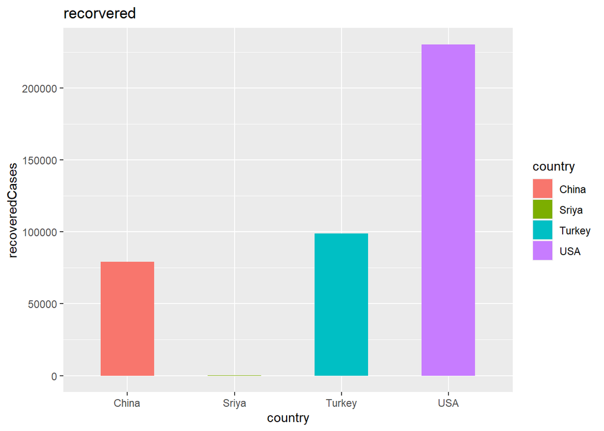

When compared the total recovered cases with the countries,among the 4 countrie total recovered cases in USA was very high and total recovered cases in Syria was very low, when compared total recovered cases in Turkey with other countries,Total recovered cases in Turkey was higher than Syria,China and lower than USA.

### Discussion

This study contain data only on 22nd of January 2020 to 12th May 2020.I used log transformed value to compare Turkey with countries because the normal value did not clear difference.when compared with USA,Turkey covid-19 effect was somewhere it because of USA was a very large country compared Turkey.In the same time Syria is one of the nearest country to Turkey but in Syria covid-19 was not highly effected.China had province also therefore, I got sum of the cases for every date given in dataset then compared with China, Compare with China covid-19 cases were highly effected in Turkey.In Turkey total number of death cases was less than recovered cases therefore most of covid-19 patients were recoveed.

### conclusion

Turkey highly effected on April month by covid-19,Total number of confirm cases 141475, total number of death cases 3894 and total number of recovered cases 98889 it shows that death cases is low and majority of the patients recovered by the doctors.

### References

1. "Turkiye'deki Guncel Durum". Ministry of Health. 18 July 2020. Retrieved 18 July 2020.
2. Jump up to:a b c "Turkey confirms first coronavirus patient, recently returned from Europe". Daily Sabah. 11 March 2020. Retrieved 11 March 2020.
3. "Saglik Bakani Koca: Son 24 saatte 7 kisi hayatini kaybetti, 293 yeni vaka goruldu". Euronews. 23 March 2020. Retrieved 24 March 2020.
4. "Saglik Bakani Koca: Turkiye de 4.haftada vaka artis hizi dususe gecti." Anadolu Agency. 14 April 2020. Retrieved 10 May 2020.
5. "Turkey's public health system faces coronavirus pandemic". DW News. 7 May 2020. Retrieved 10 May 2020.
6. Reynolds, Matt (4 March 2020). "What is coronavirus and how close is it to becoming a pandemic?". Wired UK. ISSN 1357-0978. Archived from the original on 5 March 2020. Retrieved 5 March 2020.
7. "High consequence infectious diseases (HCID); Guidance and information about high consequence infectious diseases and their management in England". GOV.UK. Archived from the original on 3 March 2020. Retrieved 17 March 2020.
8. Wintour, Patrick (23 February 2020). "Turkey and Pakistan close borders with Iran over coronavirus deaths". The Guardian.
9. Congar, Kerem (10 April 2020). "Erdogan'dan Turk Konseyi'ne koronavirus mesaji: Bu surecten guclenerek cikacagiz". Euronews.Retrieved 10 April 2020.
10. Yardimci,Tugba (14 April 2020)."Turkish politician dies due to coronavirus".Anadolu Agency.Retrieved 14 April 2020.